# Chapter 2: Descriptive Statistics - Problem Set

# 1 Introduction

This tutorial is intended to allow people to practice producing and interpreting descriptive statistics and figures. We use the Ames, Iowa data set as described in: http://jse.amstat.org/v19n3/decock.pdf. The actual data set is contained in this folder for your convenience.

This tutorial assumes some base familiarity with ggplot and the tidyverse. If you do not have that, please see previous lessons or google. For building nice plots, the *R Graphics Cookbook* by Winston Chang is a useful reference: https://r-graphics.org/ More generally, if I don’t know how to plot something, I google it and find the answer on someone’s stackexchange or something like that.

For this tutorial, we will use the following packages:

```r
library(dplyr)
```

```r
library(ggplot2)
```

# 2 Step 1: Read the Data

We want to take the data from its source (in this case, a .csv) and convert it into an *R* object.

```r
# One useful way to do this is with the rio package
ames <- rio::import('./ames.csv')

# One can also use read.csv or read.csv2 to read ames data
ames.read.csv <- read.csv2('./ames.csv', sep = ',', stringsAsFactors = F)

# Both results are valid, note that there are differing defaults in how strings are read with differing commands.  For convenience, I'm going to remove ames.read.csv
rm(ames.read.csv)
```

## 2.1 Get an Understanding of the Data:

1. Look at the top several rows of the data (hint head()).

```r
# head() is a nice way to look at the top several rows of a data set.  It gives you a quick idea as to what you're looking at
head(ames)
```

```
##   Order       PID MS.SubClass MS.Zoning Lot.Frontage Lot.Area Street Alley
## 1     1 526301100          20        RL          141    31770   Pave  <NA>
## 2     2 526350040          20        RH           80    11622   Pave  <NA>
## 3     3 526351010          20        RL           81    14267   Pave  <NA>
## 4     4 526353030          20        RL           93    11160   Pave  <NA>
## 5     5 527105010          60        RL           74    13830   Pave  <NA>
## 6     6 527105030          60        RL           78     9978   Pave  <NA>
##   Lot.Shape Land.Contour Utilities Lot.Config Land.Slope Neighborhood
## 1       IR1          Lvl    AllPub     Corner        Gtl        NAmes
## 2       Reg          Lvl    AllPub     Inside        Gtl        NAmes
## 3       IR1          Lvl    AllPub     Corner        Gtl        NAmes
## 4       Reg          Lvl    AllPub     Corner        Gtl        NAmes
## 5       IR1          Lvl    AllPub     Inside        Gtl      Gilbert
## 6       IR1          Lvl    AllPub     Inside        Gtl      Gilbert
##   Condition.1 Condition.2 Bldg.Type House.Style Overall.Qual Overall.Cond
```

[output cut: 83 more lines]

2. Find out how many fields (columns) and records (rows) exist in the data. (Note, there are many ways to do this).

```r
# Number of records (rows)
nrow(ames)
```

```
## [1] 2930
```

```r
# Number of fields (columns)
ncol(ames)
```

```
## [1] 82
```

```r
# Alternative; you just have to know that dim produces rows then columns when the object passed is a data.frame
dim(ames)
```

```
## [1] 2930   82
```

3. Identify what the fields are and learn something about them.

```r
# One way to do this is to look at the columnnames
colnames(ames)
```

```
##  [1] "Order"           "PID"             "MS.SubClass"     "MS.Zoning"
##  [5] "Lot.Frontage"    "Lot.Area"        "Street"          "Alley"
##  [9] "Lot.Shape"       "Land.Contour"    "Utilities"       "Lot.Config"
## [13] "Land.Slope"      "Neighborhood"    "Condition.1"     "Condition.2"
## [17] "Bldg.Type"       "House.Style"     "Overall.Qual"    "Overall.Cond"
## [21] "Year.Built"      "Year.Remod.Add"  "Roof.Style"      "Roof.Matl"
## [25] "Exterior.1st"    "Exterior.2nd"    "Mas.Vnr.Type"    "Mas.Vnr.Area"
## [29] "Exter.Qual"      "Exter.Cond"      "Foundation"      "Bsmt.Qual"
## [33] "Bsmt.Cond"       "Bsmt.Exposure"   "BsmtFin.Type.1"  "BsmtFin.SF.1"
## [37] "BsmtFin.Type.2"  "BsmtFin.SF.2"    "Bsmt.Unf.SF"     "Total.Bsmt.SF"
## [41] "Heating"         "Heating.QC"      "Central.Air"     "Electrical"
## [45] "X1st.Flr.SF"     "X2nd.Flr.SF"     "Low.Qual.Fin.SF" "Gr.Liv.Area"
## [49] "Bsmt.Full.Bath"  "Bsmt.Half.Bath"  "Full.Bath"       "Half.Bath"
## [53] "Bedroom.AbvGr"   "Kitchen.AbvGr"   "Kitchen.Qual"    "TotRms.AbvGrd"
## [57] "Functional"      "Fireplaces"      "Fireplace.Qu"    "Garage.Type"
## [61] "Garage.Yr.Blt"   "Garage.Finish"   "Garage.Cars"     "Garage.Area"
## [65] "Garage.Qual"     "Garage.Cond"     "Paved.Drive"     "Wood.Deck.SF"
## [69] "Open.Porch.SF"   "Enclosed.Porch"  "X3Ssn.Porch"     "Screen.Porch"
## [73] "Pool.Area"       "Pool.QC"         "Fence"           "Misc.Feature"
## [77] "Misc.Val"        "Mo.Sold"         "Yr.Sold"         "Sale.Type"
## [81] "Sale.Condition"  "SalePrice"
```

```r
# Another way to do this is to use the str() command.  It shows you both the columns and their datatypes
str(ames)
```

```
## 'data.frame':    2930 obs. of  82 variables:
##  $ Order          : int  1 2 3 4 5 6 7 8 9 10 ...
##  $ PID            : int  526301100 526350040 526351010 526353030 527105010 527105030 527127150 527145080 527146030 527162130 ...
##  $ MS.SubClass    : int  20 20 20 20 60 60 120 120 120 60 ...
##  $ MS.Zoning      : chr  "RL" "RH" "RL" "RL" ...
##  $ Lot.Frontage   : int  141 80 81 93 74 78 41 43 39 60 ...
##  $ Lot.Area       : int  31770 11622 14267 11160 13830 9978 4920 5005 5389 7500 ...
##  $ Street         : chr  "Pave" "Pave" "Pave" "Pave" ...
##  $ Alley          : chr  NA NA NA NA ...
##  $ Lot.Shape      : chr  "IR1" "Reg" "IR1" "Reg" ...
##  $ Land.Contour   : chr  "Lvl" "Lvl" "Lvl" "Lvl" ...
##  $ Utilities      : chr  "AllPub" "AllPub" "AllPub" "AllPub" ...
##  $ Lot.Config     : chr  "Corner" "Inside" "Corner" "Corner" ...
##  $ Land.Slope     : chr  "Gtl" "Gtl" "Gtl" "Gtl" ...
##  $ Neighborhood   : chr  "NAmes" "NAmes" "NAmes" "NAmes" ...
```

[output cut: 68 more lines]

```r
# Finally, summary is useful, particularly when you have numeric data.
summary(ames)
```

```
##      Order             PID             MS.SubClass      MS.Zoning
##  Min.   :   1.0   Min.   :5.263e+08   Min.   : 20.00   Length:2930
##  1st Qu.: 733.2   1st Qu.:5.285e+08   1st Qu.: 20.00   Class :character
##  Median :1465.5   Median :5.355e+08   Median : 50.00   Mode  :character
##  Mean   :1465.5   Mean   :7.145e+08   Mean   : 57.39
##  3rd Qu.:2197.8   3rd Qu.:9.072e+08   3rd Qu.: 70.00
##  Max.   :2930.0   Max.   :1.007e+09   Max.   :190.00
##
##   Lot.Frontage       Lot.Area         Street             Alley
##  Min.   : 21.00   Min.   :  1300   Length:2930        Length:2930
##  1st Qu.: 58.00   1st Qu.:  7440   Class :character   Class :character
##  Median : 68.00   Median :  9436   Mode  :character   Mode  :character
##  Mean   : 69.22   Mean   : 10148
##  3rd Qu.: 80.00   3rd Qu.: 11555
##  Max.   :313.00   Max.   :215245
##  NA's   :490
##   Lot.Shape         Land.Contour        Utilities          Lot.Config
##  Length:2930        Length:2930        Length:2930        Length:2930
##  Class :character   Class :character   Class :character   Class :character
##  Mode  :character   Mode  :character   Mode  :character   Mode  :character
##
##
##
##
##   Land.Slope        Neighborhood       Condition.1        Condition.2
##  Length:2930        Length:2930        Length:2930        Length:2930
##  Class :character   Class :character   Class :character   Class :character
##  Mode  :character   Mode  :character   Mode  :character   Mode  :character
##
##
##
##
##   Bldg.Type         House.Style         Overall.Qual     Overall.Cond
##  Length:2930        Length:2930        Min.   : 1.000   Min.   :1.000
##  Class :character   Class :character   1st Qu.: 5.000   1st Qu.:5.000
##  Mode  :character   Mode  :character   Median : 6.000   Median :5.000
##                                        Mean   : 6.095   Mean   :5.563
##                                        3rd Qu.: 7.000   3rd Qu.:6.000
##                                        Max.   :10.000   Max.   :9.000
##
```

[output cut: 113 more lines]

```
##  Min.   :    0.00   Min.   : 1.000   Min.   :2006   Length:2930
##  1st Qu.:    0.00   1st Qu.: 4.000   1st Qu.:2007   Class :character
##  Median :    0.00   Median : 6.000   Median :2008   Mode  :character
##  Mean   :   50.63   Mean   : 6.216   Mean   :2008
##  3rd Qu.:    0.00   3rd Qu.: 8.000   3rd Qu.:2009
##  Max.   :17000.00   Max.   :12.000   Max.   :2010
##
##  Sale.Condition       SalePrice
##  Length:2930        Min.   : 12789
##  Class :character   1st Qu.:129500
##  Mode  :character   Median :160000
##                     Mean   :180796
##                     3rd Qu.:213500
##                     Max.   :755000
##
```

4. Determine the number of rows that are missing at least one data record (i.e., the number of rows with an NA).

```r
# First, consider what it means for a data point to be an NA
head(is.na(ames)) # we only want to look at the first few rows of this output, so we wrap the query in head().  We can also change the global  option: options(max.print = N) where N is the number of rows you want to print
```

```
##   Order   PID MS.SubClass MS.Zoning Lot.Frontage Lot.Area Street Alley
## 1 FALSE FALSE       FALSE     FALSE        FALSE    FALSE  FALSE  TRUE
## 2 FALSE FALSE       FALSE     FALSE        FALSE    FALSE  FALSE  TRUE
## 3 FALSE FALSE       FALSE     FALSE        FALSE    FALSE  FALSE  TRUE
## 4 FALSE FALSE       FALSE     FALSE        FALSE    FALSE  FALSE  TRUE
## 5 FALSE FALSE       FALSE     FALSE        FALSE    FALSE  FALSE  TRUE
## 6 FALSE FALSE       FALSE     FALSE        FALSE    FALSE  FALSE  TRUE
##   Lot.Shape Land.Contour Utilities Lot.Config Land.Slope Neighborhood
## 1     FALSE        FALSE     FALSE      FALSE      FALSE        FALSE
## 2     FALSE        FALSE     FALSE      FALSE      FALSE        FALSE
## 3     FALSE        FALSE     FALSE      FALSE      FALSE        FALSE
## 4     FALSE        FALSE     FALSE      FALSE      FALSE        FALSE
## 5     FALSE        FALSE     FALSE      FALSE      FALSE        FALSE
## 6     FALSE        FALSE     FALSE      FALSE      FALSE        FALSE
##   Condition.1 Condition.2 Bldg.Type House.Style Overall.Qual Overall.Cond
```

[output cut: 83 more lines]

```r
# Second you can sum this by rows (recall if you sum boolean values, T is given the value 1 and false is given the value 0, NA is given the value NA)
# the rowSums function is a nice one
head(rowSums(is.na(ames)))
```

```
## 1 2 3 4 5 6
## 4 4 4 4 3 4
```

```r
# This does not tell you the total number of rows that have NAs, so we can summarize it:
# one way is to do a boolean test against the above set of numbers and then sum that test
sum(rowSums(is.na(ames)) > 0)
```

```
## [1] 2930
```

```r
# A nice alternative is the summary function which tells us something about how the number of NAs are distributed across the rows
summary(rowSums(is.na(ames)))
```

```
##    Min. 1st Qu.  Median    Mean 3rd Qu.    Max.
##   1.000   4.000   4.000   4.765   5.000  16.000
```

```r
# We can do a similar set of analysis with colSums()
colSums(is.na(ames))
```

```
##           Order             PID     MS.SubClass       MS.Zoning    Lot.Frontage
##               0               0               0               0             490
##        Lot.Area          Street           Alley       Lot.Shape    Land.Contour
##               0               0            2732               0               0
##       Utilities      Lot.Config      Land.Slope    Neighborhood     Condition.1
##               0               0               0               0               0
##     Condition.2       Bldg.Type     House.Style    Overall.Qual    Overall.Cond
##               0               0               0               0               0
##      Year.Built  Year.Remod.Add      Roof.Style       Roof.Matl    Exterior.1st
##               0               0               0               0               0
##    Exterior.2nd    Mas.Vnr.Type    Mas.Vnr.Area      Exter.Qual      Exter.Cond
##               0               0              23               0               0
##      Foundation       Bsmt.Qual       Bsmt.Cond   Bsmt.Exposure  BsmtFin.Type.1
##               0              79              79              79              79
##    BsmtFin.SF.1  BsmtFin.Type.2    BsmtFin.SF.2     Bsmt.Unf.SF   Total.Bsmt.SF
##               1              79               1               1               1
##         Heating      Heating.QC     Central.Air      Electrical     X1st.Flr.SF
##               0               0               0               0               0
##     X2nd.Flr.SF Low.Qual.Fin.SF     Gr.Liv.Area  Bsmt.Full.Bath  Bsmt.Half.Bath
##               0               0               0               2               2
##       Full.Bath       Half.Bath   Bedroom.AbvGr   Kitchen.AbvGr    Kitchen.Qual
##               0               0               0               0               0
##   TotRms.AbvGrd      Functional      Fireplaces    Fireplace.Qu     Garage.Type
##               0               0               0            1422             157
##   Garage.Yr.Blt   Garage.Finish     Garage.Cars     Garage.Area     Garage.Qual
##             159             157               1               1             158
##     Garage.Cond     Paved.Drive    Wood.Deck.SF   Open.Porch.SF  Enclosed.Porch
##             158               0               0               0               0
##     X3Ssn.Porch    Screen.Porch       Pool.Area         Pool.QC           Fence
##               0               0               0            2917            2358
##    Misc.Feature        Misc.Val         Mo.Sold         Yr.Sold       Sale.Type
##            2824               0               0               0               0
##  Sale.Condition       SalePrice
##               0               0
```

At this point, you have to make some decision about your data (e.g., drop incomplete records, provide a standard fill to incomplete records, or something else). We’re not going to do that however.

## 2.2 Select the appropriate data

Select the columns: “SalePrice” and “House.Style” and remove the rest. We’re only going to look at these for the rest of this section.

```r
# Option 1: Indexing
ames.base <- ames[,c('SalePrice', 'House.Style')]

# Option 2: dplyr
ames.dplyr <- dplyr::select(ames, SalePrice, House.Style)

# Option 3: dplyr with piping
library(dplyr)
ames.dplyr2 <- ames %>% select(SalePrice, House.Style)

# Since we only need one of these, I'll delete them all and just save over the ames data with only the two selected columns
rm(ames.base, ames.dplyr, ames.dplyr2)
ames <- dplyr::select(ames, SalePrice, House.Style)
```

Ensure that SalePrice is numeric and House.Style is a factor

```r
# We see SalePrice is an integer which is fine, but House.Style is a character, which we want to convert to a factor
str(ames)
```

```
## 'data.frame':    2930 obs. of  2 variables:
##  $ SalePrice  : int  215000 105000 172000 244000 189900 195500 213500 191500 236500 189000 ...
##  $ House.Style: chr  "1Story" "1Story" "1Story" "1Story" ...
```

```r
# Convert ames$House.Style to a factor
ames$House.Style <- as.factor(ames$House.Style)

# Check out the difference
str(ames)
```

```
## 'data.frame':    2930 obs. of  2 variables:
##  $ SalePrice  : int  215000 105000 172000 244000 189900 195500 213500 191500 236500 189000 ...
##  $ House.Style: Factor w/ 8 levels "1.5Fin","1.5Unf",..: 3 3 3 3 6 6 3 3 3 6 ...
```

# 3 Step 2. Continuous Data Descriptions

Find the maximum, minimum, median, mean, and standard deviation of the sale prices.

```r
# Maximum:
max(ames$SalePrice)
```

```
## [1] 755000
```

```r
# Minimum
min(ames$SalePrice)
```

```
## [1] 12789
```

```r
# Median
median(ames$SalePrice)
```

```
## [1] 160000
```

```r
# Mean
mean(ames$SalePrice)
```

```
## [1] 180796.1
```

```r
# Alternatively, one can get all of this very quickly using the summary function
summary(ames$SalePrice)
```

```
##    Min. 1st Qu.  Median    Mean 3rd Qu.    Max.
##   12789  129500  160000  180796  213500  755000
```

```r
# Get the standard deviation of the data
sd(ames$SalePrice)
```

```
## [1] 79886.69
```

Build & plot a probability distribution (pdf) of the ames data.

```r
# The density function provides an approximation to the probability distribution function:
ames.density <- density(ames$SalePrice)

# The density function outputs an x value (in this case, the Sale Price)
head(ames.density$x)
```

```
## [1] -21500.78 -19914.11 -18327.43 -16740.76 -15154.09 -13567.41
```

```r
# The density functino outputs a y value (in this case, the probability)
head(ames.density$y)
```

```
## [1] 2.644975e-10 3.989076e-10 5.888168e-10 8.510086e-10 1.204858e-09
## [6] 1.671855e-09
```

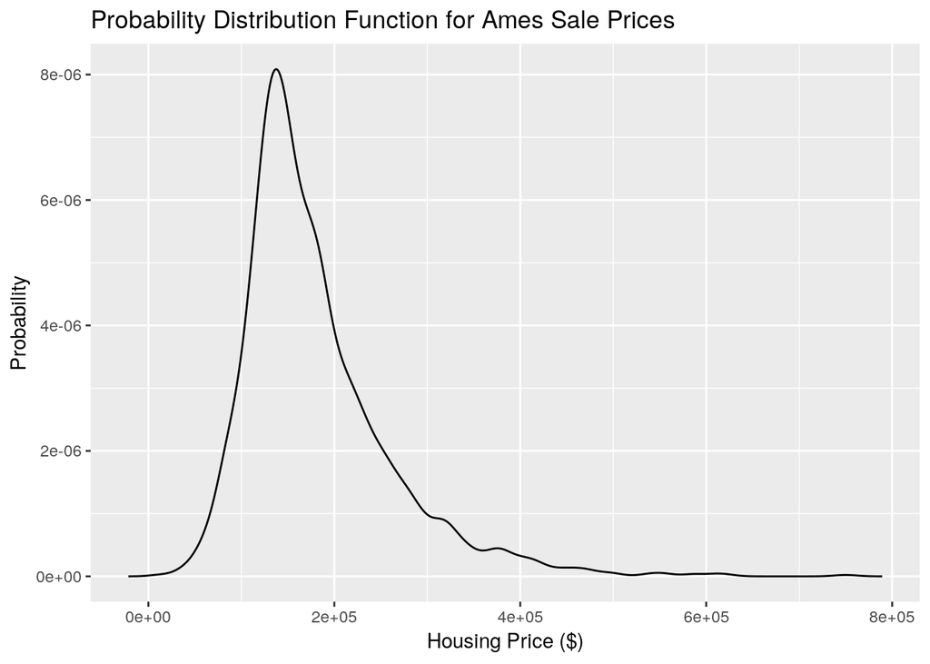

```r
# You can plot this:
ggplot() +
    geom_line(aes(x = ames.density$x, y = ames.density$y)) +
    xlab('Housing Price ($)') +
    ylab('Probability') +
    ggtitle('Probability Distribution Function for Ames Sale Prices')
```

Build an empirical cumulative density function, plot it, and find the probability that a house costs between $100,000 and $150,000

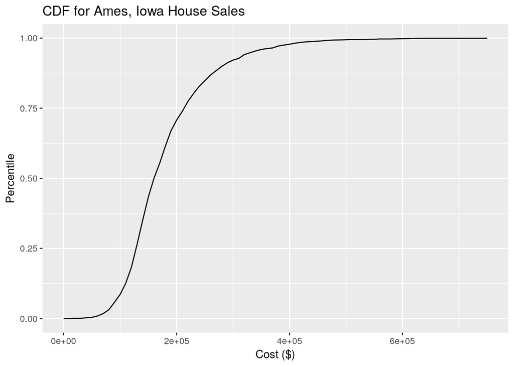

```r
ames.cdf <- ecdf(ames$SalePrice)

# Create a vector of costs
cost <- seq(0, 750000, by = 10000)
# Calculate their cumulative probability (percentile)
cum.prob <- ames.cdf(cost)
# Plot it
ggplot() +
    geom_line(aes(x = cost, y = cum.prob)) +
    ggtitle('CDF for Ames, Iowa House Sales') +
    xlab('Cost ($)') + ylab('Percentile')
```

```r
# You can assess the probability that a house will cost in a range by calculating the difference of the percentiles of the two numbers:
ames.cdf(150000) - ames.cdf(100000)
```

```
## [1] 0.3477816
```

```r
# It's about 35%
```

Find what the sale prices are for the 0, 10, 20, … percentiles (i.e. the quantiles)

```r
# The quantile function is very useful.  You can pass it an arbitrary vector
quantile(ames$SalePrice, c(0, .1, .2, .3, .4, .5, .6, .7, .8, .9, 1))
```

```
##       0%      10%      20%      30%      40%      50%      60%      70%
##  12789.0 105450.0 124000.0 135000.0 146500.0 160000.0 178536.0 199500.0
##      80%      90%     100%
## 230000.0 281241.7 755000.0
```

```r
# Note that ecdf and quantile are effectively inverses of each other (up to rounding errors)
quantile(ames$SalePrice, ecdf(ames$SalePrice)(100000))
```

```
## 8.600683%
##    100457
```

Visualize the data using a boxplot, density plot, histogram

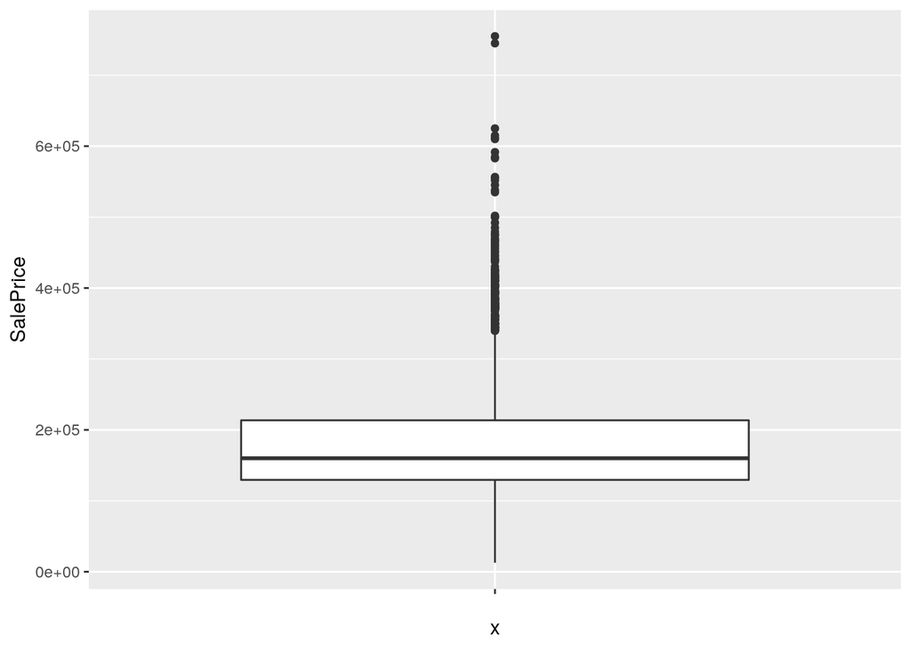

```r
# Box plot, note we are not varying by any other data type
ggplot(data = ames) + geom_boxplot(aes(x = '', y = SalePrice))
```

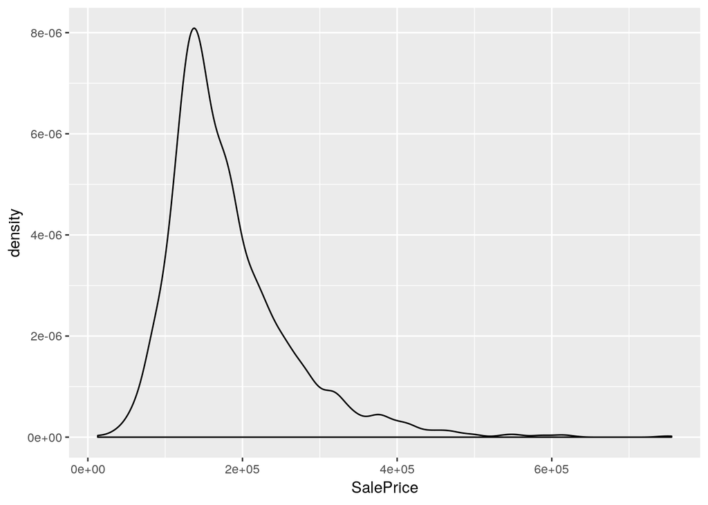

```r
# Density plot (note this is the same as what we saw when we plotted the results of Density)
ggplot(data = ames) + geom_density(aes(x = SalePrice))
```

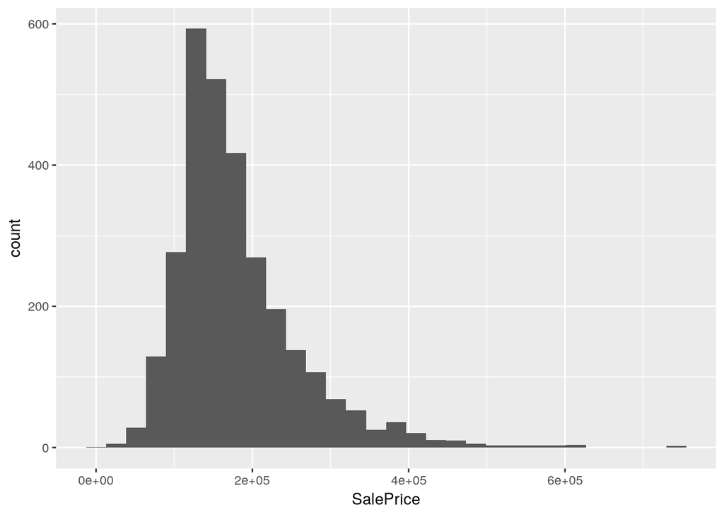

```r
# Histogram
ggplot(data = ames) + geom_histogram(aes(x = SalePrice))
```

# 4 Step 3. Categorical Data Description

For this section, note that House.Style is a categorical (in R, it is called a factor) variable.

What are the number of categories (levels) of the factor. How many records are in each level

```r
# You can find the names of the levels for the variable with levels()
levels(ames$House.Style)
```

```
## [1] "1.5Fin" "1.5Unf" "1Story" "2.5Fin" "2.5Unf" "2Story" "SFoyer" "SLvl"
```

```r
# Note that the summary function treats a factor different than a numeric data type.  It returns the levels and the number
# of observations for each level
summary(ames$House.Style)
```

```
## 1.5Fin 1.5Unf 1Story 2.5Fin 2.5Unf 2Story SFoyer   SLvl
##    314     19   1481      8     24    873     83    128
```

Plot the number of instances of each level in as a bar chart

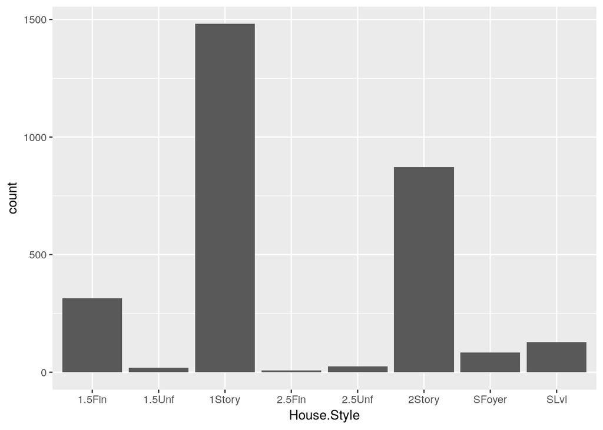

```r
# Plot as a bar chart
ggplot(data = ames) + geom_bar(aes(x = House.Style))
```

Plot the levels as a pie chart (this can be a bit tricky, I always end up googling how to do it)

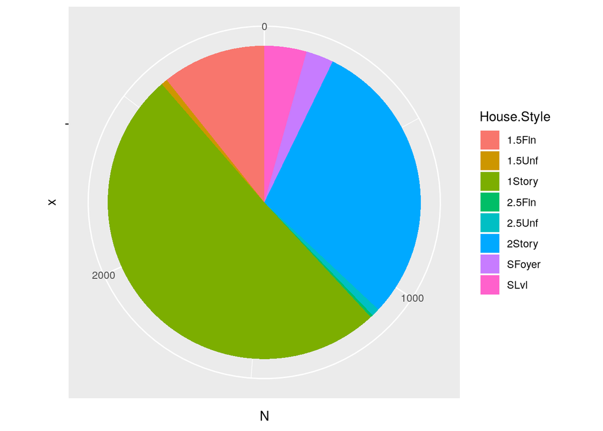

```r
# It's helpful to turn this into a single data frame where the number of records for each level is recorded
ames.levels <- ames %>% group_by(House.Style) %>% summarize(N = n())
ggplot(data = ames.levels) + # we are using the ames.levels data we just created
    geom_bar(aes(x='', y = N, fill = House.Style), stat = 'identity') + # we're building a bar chart that:
                                                                        # 1) has no x axis (everything on top of everything else),
                                                                        # 2) uses the N column for its y axis, and
                                                                        # 3) colors the fill of values based on the house style
    coord_polar('y', start = 0) # This changes the y coordinates from your normal linear to a polar type
```

```r
ames.levels
```

```
## # A tibble: 8 x 2
##   House.Style     N
##   <fct>       <int>
## 1 1.5Fin        314
## 2 1.5Unf         19
## 3 1Story       1481
## 4 2.5Fin          8
## 5 2.5Unf         24
## 6 2Story        873
## 7 SFoyer         83
## 8 SLvl          128
```

# 5 Step 4. Describe a mix of continuous and categorical data

Produce a boxplot chart where the x axis is the type of house

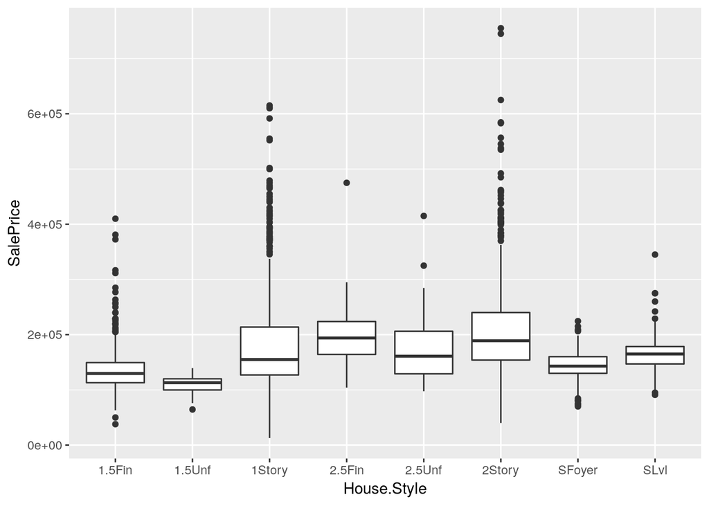

```r
ggplot(data = ames) +
    geom_boxplot(aes(x = House.Style, y = SalePrice))
```

Produce multiple histograms where each chart is for a distinct house style

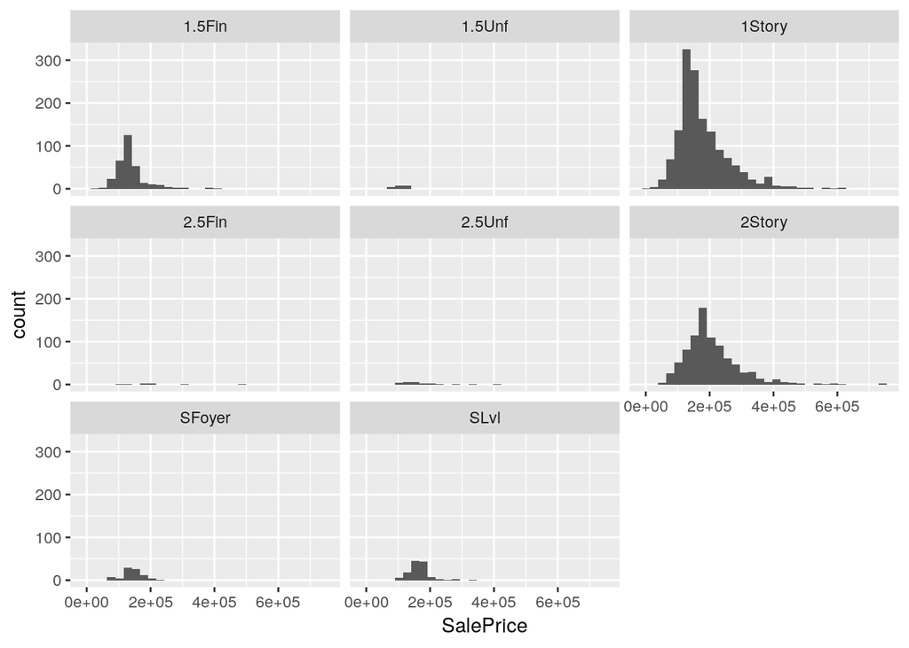

```r
ggplot(data = ames) +
    geom_histogram(aes(x = SalePrice)) +
    facet_wrap(~House.Style)
```

Produce a density plot where each house type is colored differently and overlayed on top of the other

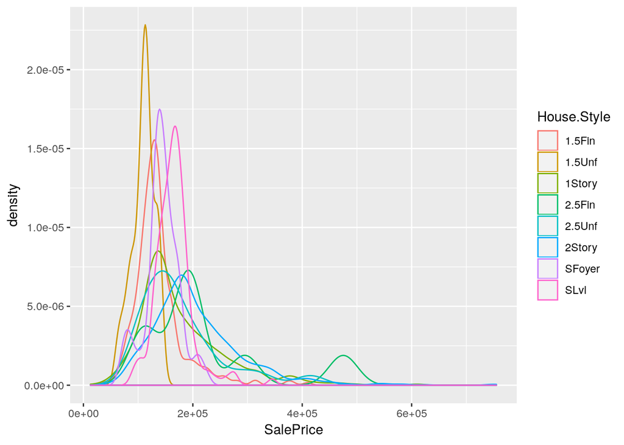

```r
ggplot(data = ames) +
    geom_density(aes(x = SalePrice, color = House.Style), fill = NA)
```

# 6 Conclusion